# Part_12_Cross_Validation

## Cross Validation Concept

When building a machine learning model, performance on the data it’s trained on isn’t enough. To truly assess whether it will work in the real world, we must test it on *unseen* examples - data the model you've never encountered before. Cross-validation is a broad family of strategies designed to estimate how well your model generalizes beyond its training set. It simulates the process of training on one set of data and validating on another to reveal issues like overfitting (when a model memorizes the training data) or underfitting (when it’s too simplistic to learn the underlying patterns).

### Train‑Test Split: The Foundation

The simplest cross-validation technique is a train‑test split: divide your labeled data into two subsets, typically 70–80 % for training and 20–30 % for testing. You fit your model to the training set, then evaluate it on the held‑out testing set. The goal is for the performance metrics - such as mean absolute percentage error (MAPE), RMSE, or accuracy - to remain consistent between train and test sets. Large discrepancies, particularly much higher error on the test set than the train set, often indicate overfitting; the model learned the training data too well, including noise, and fails to generalize.

However, even this split can be misleading. A single random division might be lucky or unlucky. That’s why practitioners often use **k‑fold cross‑validation**, where the data is split into *k* equal parts and the model is trained and evaluated *k* times - each time with a different chunk used for validation and the rest for training. This gives a more reliable estimate of model performance and helps identify variance in results.

Importantly, it's also wise to set aside a final **holdout validation set** - a portion of data never used during training or cross‑validation. This is your unbiased test set for the final evaluation, indicating real-world performance on truly unseen data.

### Python Example: Train‑Test Split (Over/Underfitting)

```python
import numpy as np
from sklearn.linear_model import LinearRegression
from sklearn.tree import DecisionTreeRegressor
from sklearn.model_selection import train_test_split
from sklearn.metrics import mean_absolute_percentage_error

# Create synthetic non-linear data
np.random.seed(42)
x = np.sort(np.random.rand(100,1)*10, axis=0)
y = np.sin(x).ravel() + np.random.normal(scale=0.1, size=100)
```

```python
# Split
X_train, X_test, y_train, y_test = train_test_split(x, y, test_size=0.2, random_state=42)

# Underfitting with Linear Regression
lr = LinearRegression().fit(X_train, y_train)

print("Linear Regression MAPE (train/test):",
      mean_absolute_percentage_error(y_train, lr.predict(X_train)),
      mean_absolute_percentage_error(y_test, lr.predict(X_test)))
```

```
Linear Regression MAPE (train/test): 1.1444229644320116 1.1511086489483937
```

```python
# Overfitting with a deep Decision Tree
dt = DecisionTreeRegressor(max_depth=None, random_state=42).fit(X_train, y_train)

print("Decision Tree MAPE (train/test):",
      mean_absolute_percentage_error(y_train, dt.predict(X_train)),
      mean_absolute_percentage_error(y_test, dt.predict(X_test)))
```

```
Decision Tree MAPE (train/test): 0.0 0.22554231512247655
```

This script demonstrates **underfitting** (high error on both train and test for a simple linear model) versus **overfitting** (very low train error, but much higher test error with an overly complex model). A well-generalizing model sits between these extremes.

### **Bias and Variance: The Core Errors**

#### **Bias**

Bias is the error introduced by approximating a real-world problem (potentially complex) with a simpler model. High bias means your model's assumptions are too strong—e.g., fitting a straight line to curved data. It leads to underfitting, with poor accuracy on both training and testing sets. Signs of high bias include large training errors and structured patterns in residuals (e.g., consistently underpredicting in a range).

**How to reduce bias**:

- Use a more flexible model (e.g., polynomial/regression tree instead of linear).
- Engineer features or apply transformations.
- Tune hyperparameters to allow more expressiveness.
- Gather more data or include domain-specific features.

#### **Variance**

Variance reflects the model’s sensitivity to fluctuations in the training set. High variance happens when a model is too flexible and captures not just patterns, but also noise and anomalies. The result: excellent training performance but disappointing results on unseen data. Such models can vary significantly with small changes in training data.

**How to reduce variance**:

- Simplify the model (prune trees, lower polynomial degrees).
- Apply regularization (e.g., Lasso, Ridge) to penalize complexity.
- Use feature selection or dimensionality reduction.
- Enrich training data and use techniques like early stopping.

#### **Bias‑Variance Tradeoff: Finding the Sweet Spot**

The art of machine learning lies in striking a balance between bias and variance. Too simple, and you're biased; too complex, and you're variant. This balance is classically illustrated with U‑shaped curves:

- The **Training Error** curve typically falls as model complexity rises.
- The **Validation/Test Error** curve initially decreases (reducing bias), then rises (increasing variance), producing a U‑shape.

The lowest point of the validation error curve represents the optimal tradeoff—your model generalizes best here.

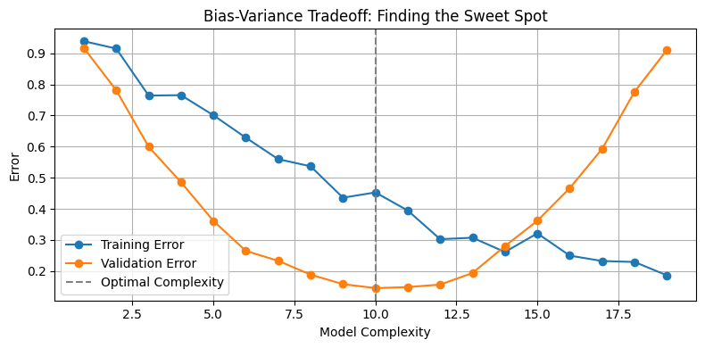

```python
import numpy as np
import matplotlib.pyplot as plt

# Simulate model complexity (e.g., polynomial degree)
complexity = np.arange(1, 20)

# Simulated error curves
# Training error: steadily decreases with complexity
training_error = np.exp(-complexity / 10) + 0.1 * np.random.rand(len(complexity))

# Validation error: initially decreases, then increases (U-shape)
validation_error = (complexity - 10)**2 / 100 + 0.1 + 0.05 * np.random.rand(len(complexity))

# Plotting
plt.figure(figsize=(8, 4))
plt.plot(complexity, training_error, label='Training Error', marker='o')
plt.plot(complexity, validation_error, label='Validation Error', marker='o')
plt.axvline(x=10, color='gray', linestyle='--', label='Optimal Complexity')
plt.title('Bias-Variance Tradeoff: Finding the Sweet Spot')
plt.xlabel('Model Complexity')
plt.ylabel('Error')
plt.legend()
plt.grid(True)
plt.tight_layout()
plt.show()
```

### **Decomposing Error Mathematically**

Understanding why a model performs well or poorly isn't just about looking at accuracy - it’s about decomposing where the error comes from. The total prediction error made by a machine learning model on unseen data (also called *generalization error*) can be broken down into three core components:

##### 1. **Bias Error**

Bias refers to the error introduced by approximating a real-world, complex problem with a much simpler model. A high-bias model is typically too constrained or rigid to capture the underlying structure of the data. In other words, it's the assumptions made by the model to make the learning task simpler.

Examples of High Bias:

- Using linear regression to fit nonlinear data
- Using a shallow decision tree when deeper splits are required
- Using too few features or overly simplified models

Effect of High Bias:

- High training error
- Underfitting: model cannot represent the true patterns in the data

##### 2. **Variance Error**

Variance measures how sensitive a model is to the specific training data it was trained on. A high-variance model performs well on training data but poorly on unseen test data - it has memorized the training examples rather than learning the general structure.

Examples of High Variance:

- Deep decision trees
- High-degree polynomial regression
- Over-parameterized neural networks with too little regularization

Effect of High Variance:

- Low training error
- High test error
- Overfitting: model captures noise as if it were signal

##### 3. **Irreducible Error (Noise)**

The irreducible error is the part of the total error that cannot be eliminated, no matter how powerful your model is. It comes from:

- Randomness in data collection
- Measurement errors
- Unobserved variables that affect the output
- Natural variability in real-world systems

Even with a perfect algorithm and unlimited data, noise ensures there is always some level of error. It's the lower limit of how well any model can do on that dataset.

### The Bias-Variance Decomposition Formula

The expected squared error of a model at a given input point $x$ is:

$$ \mathbb{E}[(y - \hat{f}(x))^2] = \underbrace{[\text{Bias}(\hat{f}(x))]^2}_{\text{error from simplifying assumptions}} + \underbrace{\text{Var}(\hat{f}(x))}_{\text{error from sensitivity to training data}} + \underbrace{\sigma^2}_{\text{irreducible error (noise)}} $$

Where:

- $y$ is the true value
- $\hat{f}(x)$ is the model's prediction
- $\mathbb{E}$ is the expectation over different training datasets
- $\sigma^2$ is the variance of the noise in the data (irreducible)

### Visualizing It

Imagine plotting the performance of various models as model complexity increases:

| Model Complexity | Bias | Variance | Total Error |
| --- | --- | --- | --- |
| Low (Simple) | High | Low | High |
| Medium | Medium | Medium | **Low (optimal)** |
| High (Complex) | Low | High | High |

In this sense, there’s a **U-shaped curve** for generalization error as complexity increases, which we try to minimize at the “sweet spot.”

**Detailed Example of Bias/Variance Calculation with `mlxtend`** For classification tasks, libraries like mlxtend offer bias/variance decomposition tools. For example:

```python
from mlxtend.evaluate import bias_variance_decomp
from sklearn.tree import DecisionTreeClassifier
from sklearn.datasets import load_iris
from sklearn.model_selection import train_test_split

X, y = load_iris(return_X_y=True)
X_train, X_test, y_train, y_test = train_test_split(X, y, test_size=0.3, random_state=123)

tree = DecisionTreeClassifier(random_state=123)
avg_loss, avg_bias, avg_var = bias_variance_decomp(
    tree, X_train, y_train, X_test, y_test, loss='0-1_loss', num_rounds=200, random_seed=123
)
print(f'Loss: {avg_loss:.3f}, Bias: {avg_bias:.3f}, Variance: {avg_var:.3f}')
```

```
Loss: 0.061, Bias: 0.044, Variance: 0.033
```

#### **Key Causes & Remedies for Bias and Variance**

| Cause | Error Type | Remedy |
| --- | --- | --- |
| Too simple model | Bias | Increase complexity, add features, tune model, gather more data |
| Too few features/data | Bias | Feature engineering, data augmentation |
| Too complex model | Variance | Regularization, pruning, early stopping, simpler feature selection |
| High dimensionality/data | Variance | Dimensionality reduction, regularization, more training samples |

Additional remedies include using ensemble techniques like **bagging**, which average high-variance models to reduce that variance without adding bias

### Types of Cross Validations

#### **1. K‑Fold Cross‑Validation**

While a simple train–test split can suffer from high variance - especially if the sample set isn't perfectly representative of the full data - K‑fold cross‑validation addresses this by dividing the dataset into *K* equally-sized “folds.” Each fold gets used once as the validation set, while the other *K–1* folds serve as training data. You then average the performance across folds for a robust estimate.

##### Steps:

1. Shuffle your dataset (unless data are ordered).
2. Split into *K* equal folds (e.g., 10 for small/medium, 5 for large).
3. For each fold *i*:
   - Train on all data except fold *i*.
   - Evaluate on fold *i*.
4. Compute mean and std of evaluation scores (e.g., accuracy or error).
5. Optionally repeat to further stabilize - **Repeated K‑Fold**.

##### Python Example:

```python
from sklearn.datasets import load_iris
from sklearn.ensemble import RandomForestClassifier
from sklearn.model_selection import KFold, cross_val_score
import numpy as np

x, y = load_iris(return_X_y=True)
model = RandomForestClassifier(n_estimators=2, random_state=42)
kf = KFold(n_splits=5, shuffle = True, random_state=42)
scores = cross_val_score(model, x, y, cv = kf, scoring='accuracy')

print("Scores:", scores)
print(f"Mean accuracy: {np.mean(scores):.4f}, Std: {np.std(scores):.4f}")
```

```
Scores: [1.         0.93333333 0.93333333 0.9        0.9       ]
Mean accuracy: 0.9333, Std: 0.0365
```

This ensures each sample is used in validation once, giving a balanced and lower-variance estimate.

#### **2. Stratified K‑Fold:**

For imbalanced classification, StratifiedKFold ensures each fold maintains class distribution. This is essential when target classes are uneven.

##### Repeated K‑Fold:

To further stabilize results, you can repeat K‑fold multiple times. For instance, using 10 folds with 3 repeats yields 30 different evaluations .

#### **3. Leave‑One‑Out Cross‑Validation (LOOCV)**

LOOCV is a special case of K‑fold with *K = N* (the number of data points). Each round you train on *N–1* samples and test on the 1 left out.

##### Characteristics:

- Optimal for very small datasets - each model nearly uses all the data.
- High variance and computational cost for large datasets (requires N models).
- Typically too expensive for anything but small samples.

##### LOOCV Pseudocode:

```
for i in range(N):
    train = all_indices != i
    test = i
    model.fit(X[train], y[train])
    preds = model.predict(X[test])
    record error
average_error = mean(all_errors)
```

#### **4. Time Series Cross‑Validation**

In time series data, temporal order matters; random splits can leak future information into training. To avoid this, we use time‑aware CV, such as expanding or sliding windows.

##### Methods:

- **Expanding Window (forward chaining)**: Train on `time ≤ t`, test on `t+1`.
- **Sliding Window**: Both train and test windows move forward in time, keeping window size fixed.
- Optionally, insert a “gap” to avoid leakage between training and test.

##### Python Example:

```python
import pandas as pd
from sklearn.model_selection import TimeSeriesSplit
from sklearn.linear_model import LinearRegression
from sklearn.metrics import mean_squared_error

tscv = TimeSeriesSplit(n_splits=5)
model = LinearRegression()
errors = []

for train_idx, test_idx in tscv.split(X):
    model.fit(X[train_idx], y[train_idx])
    preds = model.predict(X[test_idx])
    errors.append(mean_squared_error(y[test_idx], preds))

print("MSEs:", errors)
```

```
MSEs: [np.float64(0.0), np.float64(1.0), np.float64(0.018868056956335335), np.float64(0.3483620695449149), np.float64(0.12217397712069693)]
```

This ensures you only train on past data and test on future data.

#### **5. Monte Carlo Cross‑Validation (Repeated Random Sub‑Sampling)**

Also known as **ShuffleSplit** in scikit-learn, this method repeatedly selects random training/testing splits - often using a fixed ratio (e.g., 70/30) - and averages the results over many iterations.

##### Insights:

- *Large* training sets → lower bias, higher variance.
- *Smaller* training sets → higher bias, lower variance.
- Over many iterations, you can build a performance *distribution*.

##### Python Example:

```python
from sklearn.model_selection import ShuffleSplit, cross_val_score
from sklearn.linear_model import LogisticRegression
from sklearn.datasets import load_breast_cancer
import numpy as np

X, y = load_breast_cancer(return_X_y=True)
cv = ShuffleSplit(n_splits=30, train_size=0.7, test_size=0.3, random_state=42)
model = LogisticRegression(max_iter=10000)

scores = cross_val_score(model, X, y, cv=cv, scoring='accuracy')
print(f"Mean: {np.mean(scores):.3f}, Std: {np.std(scores):.3f}")
```

```
Mean: 0.954, Std: 0.015
```

Ideal when you want flexibility in train/test proportions and distributions.

#### **When to Use Which Method**

| Scenario | Suggested Method |
| --- | --- |
| Small, non-sequential data | K‑Fold (K≈10), Repeated K‑Fold |
| Imbalanced classification | StratifiedKFold |
| Very small data (<100 samples) | LOOCV |
| Time series / chronological data | TimeSeriesSplit (Expanding/Sliding window) |
| Flexible train/test proportions | Monte Carlo (ShuffleSplit) |